# At the same income, Baltic women live as long as other Europeans, Baltic men up to 4.6 years shorter

### 5.4.2 Graph 7: Heart and circulatory deaths

**Question:** do countries where more men than women die early of heart and circulatory diseases have a larger life expectancy gap?

**How to read the chart.** Each dot is one country in 2023. Left to right is the factor, here the extra deaths of men from circulatory diseases (men minus women, per 100 000, under 65). Bottom to top is the life expectancy gap. If the dots rise from bottom left to top right, more of the factor goes with a larger gap. The straight line through the dots (`geom_smooth(method = "lm")`, class 10_3) shows that direction in one stroke. The Baltic states are red.

**How to read the number.** `cor()` is not part of the course. It measures, in one number between -1 and 1, how closely the dots follow a straight line: 1 means exactly on a rising line, 0 means no straight-line pattern, -1 exactly on a falling line. As a rough guide, above 0.7 is a strong pattern, around 0.5 a moderate one, below 0.3 a weak one. A correlation says that two things go together, not that one causes the other. Because three countries can pull a line on their own, it is also computed without the Baltic states.

**A caution for the three death factors.** The life expectancy gap is calculated from death rates: when more men than women die before 65, men’s life expectancy is lower and the gap is larger. A strong correlation between men’s extra early deaths and the gap is therefore expected by design. It shows which deaths make up the gap, not why they happen. GDP and education, which are not part of the calculation, are the real tests of what goes with the gap (Graphs 10 and 11).

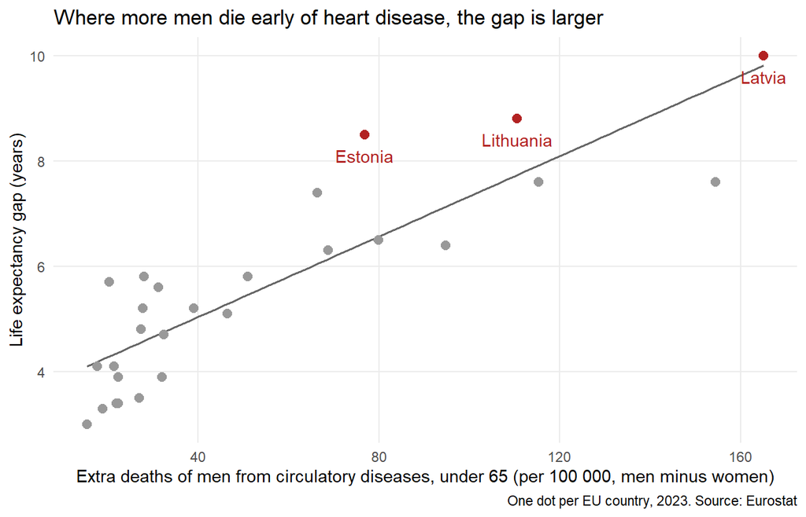

```r
# 5.4.2 Graph 7: the gap against men's extra deaths from circulatory diseases, 2023
factors_2023 |>
  ggplot(aes(x = death_circulatory, y = le_gap)) +          # one dot per country
  geom_smooth(method = "lm", formula = y ~ x, se = FALSE,
              colour = "gray40", linewidth = 0.6) +         # the straight trend line (y depends on x), without a band
  geom_point(aes(colour = baltic), size = 2.5) +            # the countries, Baltic states in red
  geom_text_repel(data = factors_2023 |> filter(baltic),    # names only for the Baltic states
                  aes(label = country), colour = "firebrick",
                  nudge_y = -0.4) +                         # labels slightly below the dots, away from the top edge
  scale_colour_manual(values = c("TRUE" = "firebrick",
                                 "FALSE" = "gray60")) +
  coord_cartesian(clip = "off") +                           # let the labels go past the edge of the panel
  labs(title = "Where more men die early of heart disease, the gap is larger",   # the title states the pattern
       x = "Extra deaths of men from circulatory diseases, under 65 (per 100 000, men minus women)",
       y = "Life expectancy gap (years)",
       caption = "One dot per EU country, 2023. Source: Eurostat") +
  theme_minimal() +
  theme(legend.position = "none",
        panel.grid.minor = element_blank())
```

```r
# 5.4.2 The correlation for Graph 7, with and without the Baltic states
factors_2023 |>
  summarise(r_all        = cor(death_circulatory, le_gap),                          # all 27 countries
            r_not_baltic = cor(death_circulatory[!baltic], le_gap[!baltic])) |>     # the 24 other countries
  kable(digits = 2, col.names = c("Correlation, all 27", "Without the Baltic states"))
```

| Correlation, all 27 | Without the Baltic states |
| --- | --- |
| 0.87 | 0.81 |

**Finding:** countries where more men than women die early of heart and circulatory diseases have larger gaps (correlation 0.87, and 0.81 without the Baltic states). Latvia has both the most extra deaths (165 per 100 000) and the largest gap (10.0 years). All three Baltic states lie above the line: their gaps are larger than heart deaths alone would predict, so other causes add to them. Bulgaria and Romania, with almost as many extra heart deaths, lie below the line, with smaller gaps (7.6 years).

### 5.4.3 Graph 8: External causes

**Question:** do countries where more men than women die early of external causes (accidents, poisoning, suicide, violence) have a larger life expectancy gap? And does this explain why the Baltic states lie above the line in Graph 7?

The chart is read in the same way as Graph 7, with the extra deaths of men from external causes from left to right. The same caution applies: these deaths are part of what makes up the gap.

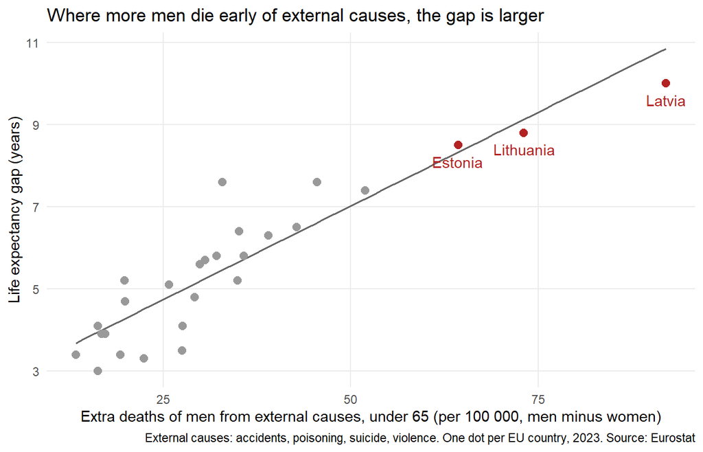

```r
# 5.4.3 Graph 8: the gap against men's extra deaths from external causes, 2023
factors_2023 |>
  ggplot(aes(x = death_external, y = le_gap)) +             # one dot per country
  geom_smooth(method = "lm", formula = y ~ x, se = FALSE,
              colour = "gray40", linewidth = 0.6) +         # the straight trend line (y depends on x), without a band
  geom_point(aes(colour = baltic), size = 2.5) +            # the countries, Baltic states in red
  geom_text_repel(data = factors_2023 |> filter(baltic),    # names only for the Baltic states
                  aes(label = country), colour = "firebrick",
                  nudge_y = -0.4) +                         # labels slightly below the dots
  scale_colour_manual(values = c("TRUE" = "firebrick",
                                 "FALSE" = "gray60")) +
  coord_cartesian(clip = "off") +                           # let the labels go past the edge of the panel
  labs(title = "Where more men die early of external causes, the gap is larger",   # the title states the pattern
       x = "Extra deaths of men from external causes, under 65 (per 100 000, men minus women)",
       y = "Life expectancy gap (years)",
       caption = "External causes: accidents, poisoning, suicide, violence. One dot per EU country, 2023. Source: Eurostat") +
  theme_minimal() +
  theme(legend.position = "none",
        panel.grid.minor = element_blank())
```

```r
# 5.4.3 The correlation for Graph 8, with and without the Baltic states
factors_2023 |>
  summarise(r_all        = cor(death_external, le_gap),                          # all 27 countries
            r_not_baltic = cor(death_external[!baltic], le_gap[!baltic])) |>     # the 24 other countries
  kable(digits = 2, col.names = c("Correlation, all 27", "Without the Baltic states"))
```

| Correlation, all 27 | Without the Baltic states |
| --- | --- |
| 0.91 | 0.85 |

**Finding:** countries where more men than women die early of external causes have larger gaps (correlation 0.91, and 0.85 without the Baltic states), the closest pattern so far. Latvia has the most extra external deaths in the EU (92 per 100 000, against 16 in the Netherlands). Unlike in Graph 7, the three Baltic states lie on the line: together with heart disease, external causes account for their large gaps. Bulgaria and Romania now lie far above the line, with large gaps but few extra external deaths, so their gaps come mainly from heart disease. The Baltic gap is the largest because Baltic men die early from both at once.

### 5.4.4 Graph 9: Alcohol-related causes

**Question:** do countries where more men than women die early of alcohol-related causes have a larger life expectancy gap? The alcohol-related causes are chronic liver disease and accidental poisoning (which includes alcohol poisoning), the two causes that pointed to alcohol in Graph 6. The same caution applies as in Graphs 7 and 8, and two more: accidental poisoning is also part of the external causes of Graph 8, and not every liver death or poisoning is caused by alcohol.

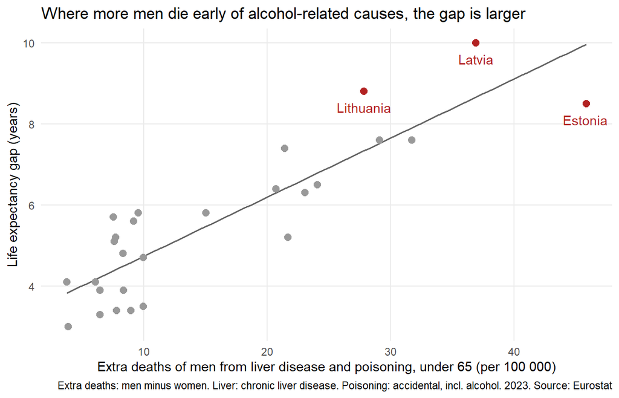

```r
# 5.4.4 Graph 9: the gap against men's extra deaths from alcohol-related causes, 2023
factors_2023 |>
  ggplot(aes(x = death_alcohol, y = le_gap)) +              # one dot per country
  geom_smooth(method = "lm", formula = y ~ x, se = FALSE,
              colour = "gray40", linewidth = 0.6) +         # the straight trend line (y depends on x), without a band
  geom_point(aes(colour = baltic), size = 2.5) +            # the countries, Baltic states in red
  geom_text_repel(data = factors_2023 |> filter(baltic),    # names only for the Baltic states
                  aes(label = country), colour = "firebrick",
                  nudge_y = -0.4) +                         # labels slightly below the dots
  scale_colour_manual(values = c("TRUE" = "firebrick",
                                 "FALSE" = "gray60")) +
  coord_cartesian(clip = "off") +                           # let the labels go past the edge of the panel
  labs(title = "Where more men die early of alcohol-related causes, the gap is larger",   # the title states the pattern
       x = "Extra deaths of men from liver disease and poisoning, under 65 (per 100 000)",   # short enough to fit
       y = "Life expectancy gap (years)",
       caption = "Extra deaths: men minus women. Liver: chronic liver disease. Poisoning: accidental, incl. alcohol. 2023. Source: Eurostat") +
  theme_minimal() +
  theme(legend.position = "none",
        panel.grid.minor = element_blank())
```

```r
# 5.4.4 The correlation for Graph 9, with and without the Baltic states
factors_2023 |>
  summarise(r_all        = cor(death_alcohol, le_gap),                          # all 27 countries
            r_not_baltic = cor(death_alcohol[!baltic], le_gap[!baltic])) |>     # the 24 other countries
  kable(digits = 2, col.names = c("Correlation, all 27", "Without the Baltic states"))
```

| Correlation, all 27 | Without the Baltic states |
| --- | --- |
| 0.88 | 0.83 |

**Finding:** countries where more men than women die early of liver disease and accidental poisoning have larger gaps (correlation 0.88, and 0.83 without the Baltic states). Estonia has the most of these extra deaths in the EU (46 per 100 000), ahead of Latvia (37) and Lithuania (28), but it lies below the line, with a smaller gap than this would predict. Latvia and Lithuania lie above it. Alcohol-related deaths matter in all three Baltic states, but they do not line up with the gap in the same way in each. Because accidental poisoning is also part of the external causes in Graph 8, this graph is not a fully separate piece of evidence.

### 5.4.5 Graph 10: GDP per capita

**Question:** do poorer countries have larger life expectancy gaps, and are the Baltic gaps larger than their income would predict?

Unlike the death factors, GDP is not part of how the gap is calculated, so this is a real test of something outside the deaths. A falling line means that richer countries have smaller gaps. Luxembourg and Ireland are far to the right for reasons that say little about how well off their residents are (see 3.4.3), so, as decided in Section 3, the trend line is drawn twice: with all 27 countries (solid) and without these two (dashed). Both countries are labelled in gray.

[figure not shown]

```r
# 5.4.5 Graph 10: the gap against GDP per capita, with and without Luxembourg and Ireland, 2023
factors_without_lu_ie <- factors_2023 |>
  filter(!country_code %in% c("LU", "IE"))                    # the 25 countries without the two outliers

factors_2023 |>
  ggplot(aes(x = gdp_pps_index, y = le_gap)) +                # one dot per country
  geom_smooth(method = "lm", formula = y ~ x, se = FALSE,
              colour = "gray40", linewidth = 0.6) +           # trend line, all 27 countries
  geom_smooth(data = factors_without_lu_ie,
              method = "lm", formula = y ~ x, se = FALSE,
              colour = "gray40", linewidth = 0.6,
              linetype = "dashed") +                          # trend line without Luxembourg and Ireland
  geom_point(aes(colour = baltic), size = 2.5) +              # the countries, Baltic states in red
  geom_text_repel(data = factors_2023 |> filter(baltic),      # names of the Baltic states
                  aes(label = country), colour = "firebrick") +
  geom_text_repel(data = factors_2023 |>
                    filter(country_code %in% c("LU", "IE", "EL")),   # names of the two outliers and Greece
                  aes(label = country), colour = "gray40") +
  scale_colour_manual(values = c("TRUE" = "firebrick",
                                 "FALSE" = "gray60")) +
  coord_cartesian(clip = "off") +                             # let the labels go past the edge of the panel
  labs(title = "The Baltic gaps are far larger than their income would predict",   # the title states the finding
       x = "GDP per capita in PPS (EU27 = 100)",
       y = "Life expectancy gap (years)",
       caption = "Solid line: all 27 countries. Dashed line: without Luxembourg and Ireland. 2023. Source: Eurostat") +
  theme_minimal() +
  theme(legend.position = "none",
        panel.grid.minor = element_blank())
```

```r
# 5.4.5 The correlation for Graph 10: all countries, without the Baltic states, without Luxembourg and Ireland
factors_2023 |>
  summarise(r_all        = cor(gdp_pps_index, le_gap),                                   # all 27 countries
            r_not_baltic = cor(gdp_pps_index[!baltic], le_gap[!baltic]),                 # without the Baltic states
            r_not_lu_ie  = cor(gdp_pps_index[!country_code %in% c("LU", "IE")],
                               le_gap[!country_code %in% c("LU", "IE")])) |>             # without Luxembourg and Ireland
  kable(digits = 2, col.names = c("Correlation, all 27", "Without the Baltic states",
                                  "Without Luxembourg and Ireland"))
```

| Correlation, all 27 | Without the Baltic states | Without Luxembourg and Ireland |
| --- | --- | --- |
| -0.61 | -0.65 | -0.75 |

**Finding:** richer countries have smaller gaps (correlation -0.61). Luxembourg and Ireland flatten the line: without them the pattern is clearly stronger (-0.75, the dashed line), which confirms the decision in 3.4.3 to check them separately. Most importantly, the three Baltic states lie far above both lines: their gaps are about 2 to 2.7 years larger than their income would predict. Latvia and Greece are about equally rich (GDP index 70 and 68), but Latvia’s gap is twice as large (10.0 years against 5.1). Being poorer is part of the picture, but it does not explain the Baltic gap.

### 5.4.6 Graph 11: The education gap

**Question:** do countries where young women are much more educated than young men have a larger life expectancy gap (hypothesis 5)?

Like GDP, education is not part of how the gap is calculated. The education gap is measured among 25 to 34 year olds, a younger generation than the men who die before 65 today, so it describes how a country is changing rather than the people whose deaths make up the gap.

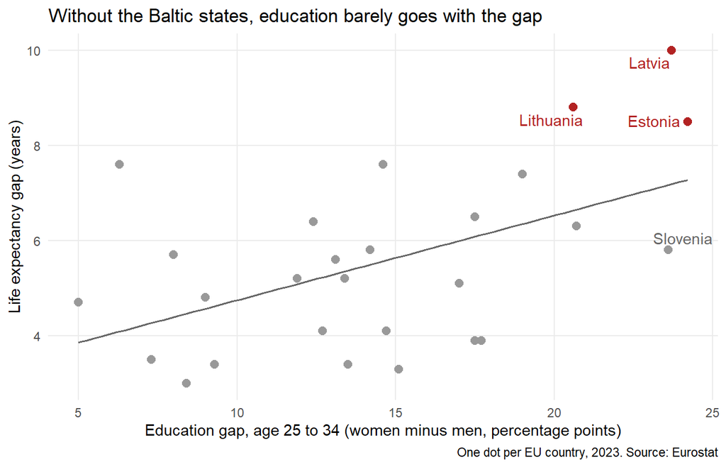

```r
# 5.4.6 Graph 11: the gap against the education gap between young women and men, 2023
factors_2023 |>
  ggplot(aes(x = tertiary_gap, y = le_gap)) +               # one dot per country
  geom_smooth(method = "lm", formula = y ~ x, se = FALSE,
              colour = "gray40", linewidth = 0.6) +         # the straight trend line, without a band
  geom_point(aes(colour = baltic), size = 2.5) +            # the countries, Baltic states in red
  geom_text_repel(data = factors_2023 |> filter(baltic),    # names of the Baltic states
                  aes(label = country), colour = "firebrick") +
  geom_text_repel(data = factors_2023 |>
                    filter(country_code == "SI"),           # Slovenia, the useful comparison
                  aes(label = country), colour = "gray40") +
  scale_colour_manual(values = c("TRUE" = "firebrick",
                                 "FALSE" = "gray60")) +
  coord_cartesian(clip = "off") +                           # let the labels go past the edge of the panel
  labs(title = "Without the Baltic states, education barely goes with the gap",   # the title states the finding
       x = "Education gap, age 25 to 34 (women minus men, percentage points)",
       y = "Life expectancy gap (years)",
       caption = "One dot per EU country, 2023. Source: Eurostat") +
  theme_minimal() +
  theme(legend.position = "none",
        panel.grid.minor = element_blank())
```

```r
# 5.4.6 The correlation for Graph 11, with and without the Baltic states
factors_2023 |>
  summarise(r_all        = cor(tertiary_gap, le_gap),                          # all 27 countries
            r_not_baltic = cor(tertiary_gap[!baltic], le_gap[!baltic])) |>     # the 24 other countries
  kable(digits = 2, col.names = c("Correlation, all 27", "Without the Baltic states"))
```

| Correlation, all 27 | Without the Baltic states |
| --- | --- |
| 0.52 | 0.22 |

**Finding:** across all 27 countries, a larger education gap goes moderately with a larger life expectancy gap (correlation 0.52). Without the three Baltic states, the pattern almost disappears (0.22). The Baltic states have both large education gaps (Estonia 24.2, Latvia 23.7, Lithuania 20.6 percentage points) and large life expectancy gaps, and they alone pull the line up. Slovenia has almost the same education gap as Latvia (23.6) but a much smaller life expectancy gap (5.8 years against 10.0). Hypothesis 5 is therefore not supported across Europe, and it is kept as a dead end in the appendix.

### 5.4.7 The five factors side by side

The five correlations in one table, from the stacked table `factors_long` of 5.4.1. `group_by(factor)` computes them once per factor.

```r
# 5.4.7 The correlation of each factor with the gap, with and without the Baltic states
factors_long |>
  group_by(factor) |>                                                   # once per factor
  summarise(r_all         = cor(value, le_gap),                         # all 27 countries
            r_not_baltic  = cor(value[!baltic], le_gap[!baltic]),       # the 24 other countries
            .groups = "drop") |>
  kable(digits = 2,                                                     # two decimals for correlations
        col.names = c("Factor", "Correlation, all 27", "Without the Baltic states"))
```

| Factor | Correlation, all 27 | Without the Baltic states |
| --- | --- | --- |
| 1 Circulatory deaths, men’s excess | 0.87 | 0.81 |
| 2 External deaths, men’s excess | 0.91 | 0.85 |
| 3 Alcohol-related deaths, men’s excess | 0.88 | 0.83 |
| 4 GDP per capita (EU27 = 100) | -0.61 | -0.65 |
| 5 Education gap (women minus men, % points) | 0.52 | 0.22 |

**What it shows:** the three death factors go closely with the gap (0.87 to 0.91), and stay strong without the Baltic states (0.81 to 0.85). GDP goes with it in the opposite direction (-0.61, richer countries have smaller gaps). The education gap goes with it only through the Baltic states (0.52, but 0.22 without them).

**What this means:** the life expectancy gap is made up mainly of men’s early deaths from heart and circulatory diseases and from external causes, with alcohol-related deaths overlapping both. This pattern holds across Europe, not only in the Baltic states. Wealth goes with smaller gaps, but the Baltic gaps are about two years larger than their income would predict, and education does not explain them. The next question is whether Baltic men fall below the European pattern while Baltic women do not.

### 5.4.8 Graph 16: A direct measure, alcohol consumption

**Question:** do countries where people drink more alcohol have a larger life expectancy gap? Graph 9 could only show alcohol indirectly, through deaths. This graph uses WHO’s estimate of how much is drunk (2.6). Two differences from Graphs 7 to 11: the alcohol data ends in 2020, so the graph uses **2019**, the last year before COVID and the same year as the robustness check in 5.9; and the figure is for women and men together, not for men alone.

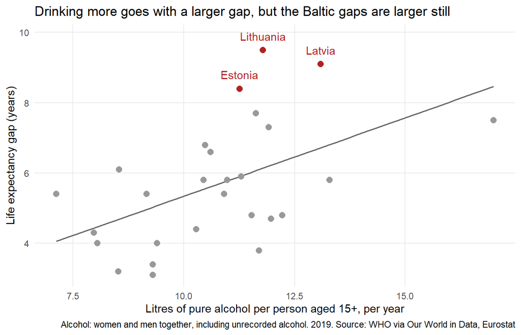

```r
# 5.4.8 Graph 16: the gap against litres of pure alcohol per person, 2019
alcohol_2019 <- gap_panel |>
  filter(year == 2019)                                      # the last year before COVID, one row per country

alcohol_2019 |>
  ggplot(aes(x = alcohol_litres, y = le_gap)) +             # one dot per country
  geom_smooth(method = "lm", formula = y ~ x, se = FALSE,
              colour = "gray40", linewidth = 0.6) +         # the straight trend line (y depends on x), without a band
  geom_point(aes(colour = baltic), size = 2.5) +            # the countries, Baltic states in red
  geom_text_repel(data = alcohol_2019 |> filter(baltic),    # names only for the Baltic states
                  aes(label = country), colour = "firebrick",
                  nudge_y = 0.4) +                          # labels slightly above the dots
  scale_colour_manual(values = c("TRUE" = "firebrick",
                                 "FALSE" = "gray60")) +
  coord_cartesian(clip = "off") +                           # let the labels go past the edge of the panel
  labs(title = "Drinking more goes with a larger gap, but the Baltic gaps are larger still",   # the title states the pattern
       x = "Litres of pure alcohol per person aged 15+, per year",
       y = "Life expectancy gap (years)",
       caption = "Alcohol: women and men together, including unrecorded alcohol. 2019. Source: WHO via Our World in Data, Eurostat") +
  theme_minimal() +
  theme(legend.position = "none",
        panel.grid.minor = element_blank())
```

```r
# 5.4.8 The correlation for Graph 16, with and without the Baltic states
alcohol_2019 |>
  summarise(r_all        = cor(alcohol_litres, le_gap),                          # all 27 countries
            r_not_baltic = cor(alcohol_litres[!baltic], le_gap[!baltic])) |>     # the 24 other countries
  kable(digits = 2, col.names = c("Correlation, all 27", "Without the Baltic states"))
```

| Correlation, all 27 | Without the Baltic states |
| --- | --- |
| 0.52 | 0.51 |

**Finding:** countries where more alcohol is drunk tend to have larger gaps, but the link is only moderate (correlation 0.52, and 0.51 without the Baltic states). The three Baltic states all lie well above the line: their gaps are 2.4 to 3.4 years larger than their drinking would predict. Latvia (13.1 litres) and Lithuania (11.8) drink a lot, but so do Czechia (13.3), Germany (12.2) and Austria (12.0), whose gaps are much smaller (4.7 to 5.8 years). Romania drinks the most in the EU (17.0 litres) with a gap of 7.5 years. Hypothesis 3 is supported only partly: how much a country drinks goes with the gap, but it does not explain why the Baltic gaps are so large.

**What this means:** the amount of alcohol alone does not separate the Baltic states from the rest of the EU. Alcohol-related deaths did (Graph 9, correlation 0.88), the amount drunk does much less. This fits the idea that how and by whom alcohol is drunk matters more than the national average, for example heavy drinking concentrated among men. This table cannot show that, because it is not by sex and does not measure drinking patterns, so it is named as a limit in Section 7.

## 5.5 Do Baltic men fall below the European pattern?

### 5.5.1 Graph 12: Baltic women and men against countries of similar income

**Question:** do Baltic women live about as long as women in EU countries of similar income, while Baltic men live much shorter lives than men there?

**Countries of similar income.** In 2024 the GDP index of the Baltic states lies between 69 (Latvia) and 87 (Lithuania). The comparison group is every other EU country with a GDP index between 60 and 90: Bulgaria, Croatia, Czechia, Greece, Hungary, Poland, Portugal, Romania, Slovakia and Slovenia, ten countries. Comparing with equally rich countries takes income out of the comparison: what is left is the difference that income does not explain. The latest year, 2024, is used, because neither life expectancy nor GDP needs the deaths data.

First the averages of the two groups, for women and for men.

```r
# 5.5.1 Average life expectancy of women and men: the Baltic states and countries of similar income, 2024
gap_2024 <- gap_panel |>
  filter(year == 2024)                                          # the latest year, one row per country

similar_income <- gap_2024 |>
  filter(!baltic,                                               # not a Baltic state
         gdp_pps_index >= 60, gdp_pps_index <= 90)              # but about as rich: GDP index 60 to 90

similar_income |> pull(country)                                 # the ten comparison countries
```

```
 [1] "Bulgaria" "Czechia"  "Greece"   "Croatia"  "Hungary"  "Poland"
 [7] "Portugal" "Romania"  "Slovenia" "Slovakia"
```

```r
similar_women <- mean(similar_income$le_women)                  # their average, women
similar_men   <- mean(similar_income$le_men)                    # their average, men

gap_2024 |>
  filter(baltic) |>                                             # the three Baltic states
  summarise(women = mean(le_women), men = mean(le_men)) |>      # their averages
  mutate(group = "Baltic states") |>
  bind_rows(tibble(group = "Countries of similar income",       # add the comparison row
                   women = similar_women, men = similar_men)) |>
  select(group, women, men) |>
  kable(digits = 1, col.names = c("Group", "Women (years)", "Men (years)"))
```

| Group | Women (years) | Men (years) |
| --- | --- | --- |
| Baltic states | 82.1 | 73.2 |
| Countries of similar income | 82.3 | 76.0 |

**What it shows:** the ten comparison countries are Bulgaria, Croatia, Czechia, Greece, Hungary, Poland, Portugal, Romania, Slovakia and Slovenia. Baltic women live on average 82.1 years, as long as women in the countries of similar income (82.3). Baltic men live 73.2 years, 2.8 years shorter than men there (76.0).

Then each Baltic country on its own: how many years longer or shorter its women and men live than the average women and men in the countries of similar income. A bar to the left (negative) means shorter lives.

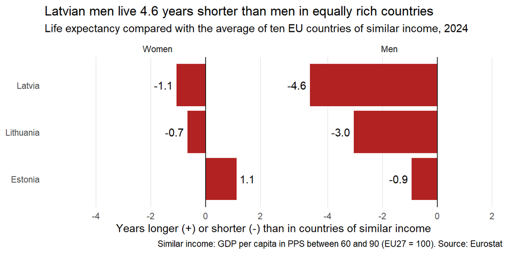

```r
# 5.5.1 Graph 12: years longer or shorter than in countries of similar income, each Baltic state, 2024
gap_2024 |>
  filter(baltic) |>                                             # the three Baltic states
  mutate(Women = le_women - similar_women,                      # difference from the comparison group, women
         Men   = le_men   - similar_men) |>                     # and men
  select(country, Women, Men) |>
  pivot_longer(cols = c(Women, Men),                            # women and men into one column
               names_to = "sex", values_to = "difference") |>
  mutate(sex = factor(sex, levels = c("Women", "Men"))) |>      # women in the left panel, men in the right
  mutate(country = fct_reorder(country, difference,
                               .fun = min, .desc = TRUE)) |>    # sort by the men's (lowest) value, largest shortfall on top
  ggplot(aes(x = country, y = difference)) +
  geom_col(fill = "firebrick") +                                # bar length = years longer (+) or shorter (-)
  geom_hline(yintercept = 0) +                                  # 0 = the same as in countries of similar income
  geom_text(aes(label = sprintf("%.1f", difference),           # the number at the end of each bar, always one decimal
                hjust = if_else(difference < 0, 1.2, -0.2))) +  # outside the bar, left or right
  coord_flip() +                                                # bars sideways, names readable
  facet_wrap(~ sex) +                                           # one panel for women, one for men
  scale_y_continuous(limits = c(-5.5, 2)) +                     # room for the numbers
  labs(title = "Latvian men live 4.6 years shorter than men in equally rich countries",   # the finding
       subtitle = "Life expectancy compared with the average of ten EU countries of similar income, 2024",
       x = NULL,
       y = "Years longer (+) or shorter (-) than in countries of similar income",
       caption = "Similar income: GDP per capita in PPS between 60 and 90 (EU27 = 100). Source: Eurostat") +
  theme_minimal() +
  theme(panel.grid.minor = element_blank(),
        panel.grid.major.y = element_blank())
```

**Finding:** compared with equally rich EU countries, Baltic women live about as long: between 1.1 years shorter (Latvia) and 1.1 years longer (Estonia). Baltic men live shorter lives in all three countries: 4.6 years shorter in Latvia, 3.0 in Lithuania and 0.9 in Estonia. Income does not explain the Baltic gap: at the same level of income, it is the men, not the women, who fall behind. This supports hypothesis 4.

**What this means:** the Baltic life expectancy gap is a gap of men. Baltic women live as long as women in other EU countries of the same income, while Baltic men, especially in Latvia and Lithuania, die years earlier. Their extra early deaths come mainly from heart disease and external causes such as poisoning, suicide and drowning, several of them linked to alcohol (5.3 and 5.4).

## 5.6 The gap is about the men

### 5.6.1 Graph 13: Women’s and men’s life expectancy, country by country

**Question:** does the life expectancy of men differ more between EU countries than that of women?

Each country is one row, with two dots: an open circle for women and a filled dot for men, joined by a gray line, the gap. The rows are sorted by men’s life expectancy. If women’s dots stay in a narrow band while men’s dots spread far, the differences in the gap come mainly from the men. `geom_segment()` (not part of the course) draws the line from one value to the other.

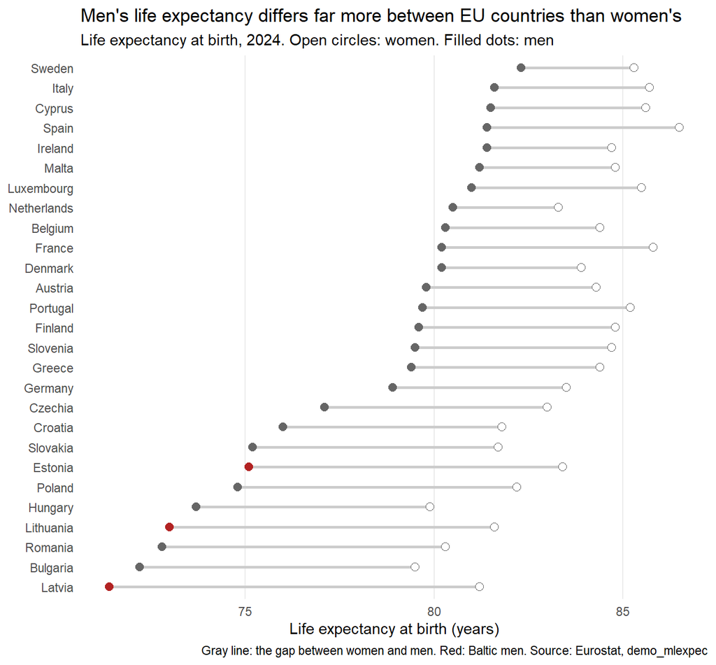

```r
# 5.6.1 Graph 13: women's and men's life expectancy in each country, sorted by men, 2024
gap_2024 |>
  mutate(country = fct_reorder(country, le_men)) |>                     # sort the countries by men's life expectancy
  ggplot(aes(y = country)) +
  geom_segment(aes(x = le_men, xend = le_women,
                   yend = country), colour = "gray80", linewidth = 1) +  # the gap, from men to women
  geom_point(aes(x = le_women), shape = 21, fill = "white",
             colour = "gray40", size = 2.5) +                           # women: open circles
  geom_point(aes(x = le_men, colour = baltic), size = 2.5) +            # men: filled dots, Baltic states in red
  scale_colour_manual(values = c("TRUE" = "firebrick",
                                 "FALSE" = "gray40")) +
  labs(title = "Men's life expectancy differs far more between EU countries than women's",   # the finding
       subtitle = "Life expectancy at birth, 2024. Open circles: women. Filled dots: men",
       x = "Life expectancy at birth (years)",
       y = NULL,
       caption = "Gray line: the gap between women and men. Red: Baltic men. Source: Eurostat, demo_mlexpec") +
  theme_minimal() +
  theme(legend.position = "none",
        panel.grid.minor = element_blank(),
        panel.grid.major.y = element_blank())
```

```r
# 5.6.1 How far women and men spread across the 27 countries, and how each goes with the gap
gap_2024 |>
  summarise(spread_women = sd(le_women),                 # standard deviation: the typical distance from the average
            spread_men   = sd(le_men),
            r_gap_women  = cor(le_women, le_gap),        # how women's life expectancy goes with the gap
            r_gap_men    = cor(le_men, le_gap)) |>       # how men's life expectancy goes with the gap
  kable(digits = 2, col.names = c("Spread, women (years)", "Spread, men (years)",
                                  "Correlation with gap, women", "Correlation with gap, men"))
```

| Spread, women (years) | Spread, men (years) | Correlation with gap, women | Correlation with gap, men |
| --- | --- | --- | --- |
| 1.94 | 3.39 | -0.65 | -0.9 |

**Finding:** women’s life expectancy stays in a narrow band, from 79.5 years (Bulgaria) to 86.5 (Spain), while men’s spreads much wider, from 71.4 (Latvia) to 82.3 (Sweden). The typical distance from the average is 1.9 years for women and 3.4 years for men, almost twice as much. The gap goes much more closely with men’s life expectancy (correlation -0.90) than with women’s (-0.65): where the gap is large, it is mainly because men live short lives, not because women live long ones. Latvian men have the lowest life expectancy in the EU, Lithuanian men the fourth lowest, while Latvian and Lithuanian women (81.2 and 81.6 years) are in the lower half of the women’s band, but not at its bottom.

## 5.7 Two neighbours, two paths

### 5.7.1 Graph 14: Men’s early deaths in the Baltic states over time

**Question:** Lithuania narrowed its gap more than any other EU country, while Latvia’s gap did not shrink (Graph 4). Which causes of death changed among men under 65 in the three Baltic states between 2015 and 2023?

The chart shows men’s death rates under 65 (per 100 000), not the gap between men and women, so that the change among men can be followed directly. One panel per cause: all causes, circulatory diseases, external causes, accidental poisoning and chronic liver disease. The three Baltic states are three lines in clearly different colours (purple and teal from the viridis palette, plus orange, because the third viridis colour, yellow, is hard to see on white), and the average of the other 24 EU countries is a dashed gray line for comparison.

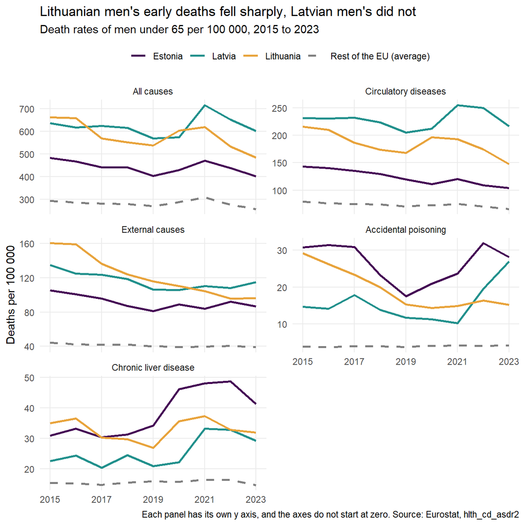

```r
# 5.7.1 Graph 14: men's death rates under 65 by cause, Baltic states and the rest of the EU, 2015 to 2023
causes_over_time <- c("TOTAL"       = "All causes",
                      "I"           = "Circulatory diseases",
                      "V01-Y89"     = "External causes",
                      "X40-X49"     = "Accidental poisoning",
                      "K70_K73_K74" = "Chronic liver disease")             # code = readable name

men_over_time <- deaths_by_cause |>
  filter(cause_code %in% names(causes_over_time)) |>                     # the five causes
  mutate(cause = causes_over_time[cause_code],                           # look up the readable name
         cause = factor(cause, levels = causes_over_time))               # panels in this order

rest_of_eu <- men_over_time |>
  filter(!baltic) |>                                                     # the 24 other countries
  group_by(year, cause) |>
  summarise(death_men = mean(death_men), .groups = "drop") |>           # their average, year by year
  mutate(country = "Rest of the EU (average)")

men_over_time |>
  filter(baltic) |>                                                      # the three Baltic states
  select(year, cause, death_men, country) |>
  bind_rows(rest_of_eu) |>                                               # add the comparison line
  ggplot(aes(x = year, y = death_men, colour = country, linetype = country)) +
  geom_line(linewidth = 0.9) +                                           # one line per country
  facet_wrap(~ cause, scales = "free_y", ncol = 2) +                     # one panel per cause, own y axis
  scale_colour_manual(values = c("Estonia" = "#440154", "Latvia" = "#21908C",
                                 "Lithuania" = "#E8A33B",                # three distinct colours
                                 "Rest of the EU (average)" = "gray50")) +
  scale_linetype_manual(values = c("Estonia" = "solid", "Latvia" = "solid", "Lithuania" = "solid",
                                   "Rest of the EU (average)" = "dashed")) +
  scale_x_continuous(breaks = c(2015, 2017, 2019, 2021, 2023)) +
  labs(title = "Lithuanian men's early deaths fell sharply, Latvian men's did not",   # the finding
       subtitle = "Death rates of men under 65 per 100 000, 2015 to 2023",
       x = NULL, y = "Deaths per 100 000", colour = NULL, linetype = NULL,
       caption = "Each panel has its own y axis, and the axes do not start at zero. Source: Eurostat, hlth_cd_asdr2") +
  theme_minimal() +
  theme(legend.position = "top",
        panel.grid.minor = element_blank())
```

**Finding:** in all five panels, Baltic men under 65 die far more often than the average man in the rest of the EU, whose rates stay almost flat. The three countries moved differently. Lithuanian men’s death rate from all causes fell by about a quarter, from 663 per 100 000 in 2015 to 485 in 2023, with the largest fall in external causes (from 160 to 96, from the highest of the three to below Latvia) and accidental poisoning, which halved (from 29 to 15). The fall starts in 2017, the year in which Lithuania’s life expectancy gap first narrowed (Graph 4). Latvian men’s death rate barely changed and rose sharply in 2021, a COVID-19 year, to 717. Their deaths from accidental poisoning have almost tripled since 2021 (from 10 to 27). In Estonia, deaths from chronic liver disease rose from 34 in 2019 to 49 in 2022. The data shows when the rates changed, not why. Whether changes in alcohol policy played a part would need a source outside this data.

### 5.7.2 Graph 17: Drinking in the Baltic states over time

**Question:** did the amount of alcohol drunk change differently in the three Baltic states between 2015 and 2020, the years the alcohol data covers? The chart uses the same colours as Graph 14, with the average of the other 24 EU countries as a dashed gray line. The figure is for women and men together.

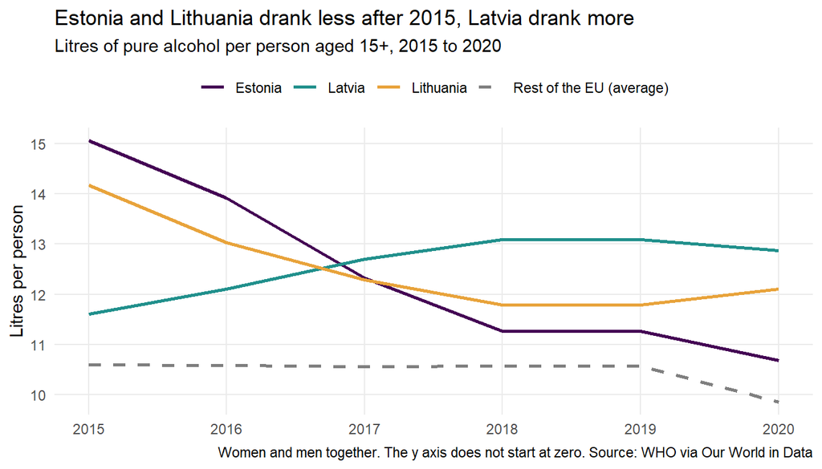

```r
# 5.7.2 Graph 17: litres of pure alcohol per person, Baltic states and the rest of the EU, 2015 to 2020
alcohol_over_time <- gap_panel |>
  filter(year <= 2020)                                                   # the years with alcohol data

alcohol_rest_of_eu <- alcohol_over_time |>
  filter(!baltic) |>                                                     # the 24 other countries
  group_by(year) |>
  summarise(alcohol_litres = mean(alcohol_litres), .groups = "drop") |>  # their average, year by year
  mutate(country = "Rest of the EU (average)")

alcohol_over_time |>
  filter(baltic) |>                                                      # the three Baltic states
  select(year, alcohol_litres, country) |>
  bind_rows(alcohol_rest_of_eu) |>                                       # add the comparison line
  ggplot(aes(x = year, y = alcohol_litres, colour = country, linetype = country)) +
  geom_line(linewidth = 0.9) +                                           # one line per country
  scale_colour_manual(values = c("Estonia" = "#440154", "Latvia" = "#21908C",
                                 "Lithuania" = "#E8A33B",                # the same colours as Graph 14
                                 "Rest of the EU (average)" = "gray50")) +
  scale_linetype_manual(values = c("Estonia" = "solid", "Latvia" = "solid", "Lithuania" = "solid",
                                   "Rest of the EU (average)" = "dashed")) +
  labs(title = "Estonia and Lithuania drank less after 2015, Latvia drank more",   # the finding
       subtitle = "Litres of pure alcohol per person aged 15+, 2015 to 2020",
       x = NULL, y = "Litres per person", colour = NULL, linetype = NULL,
       caption = "Women and men together. The y axis does not start at zero. Source: WHO via Our World in Data") +
  theme_minimal() +
  theme(legend.position = "top",
        panel.grid.minor = element_blank())
```

**Finding:** in 2015 Estonia (15.1 litres) and Lithuania (14.2) drank far more than the rest of the EU (10.6), and Latvia (11.6) only a little more. By 2020 the order had turned around. Estonia fell to 10.7 litres and Lithuania to 12.1, most of it between 2015 and 2018, while Latvia rose to 12.9 and became the heaviest-drinking Baltic state. The rest of the EU stayed at about 10.6 litres until it dropped to 9.9 in 2020, a COVID-19 year. Lithuania’s fall in drinking came in the same years as the fall in its men’s early deaths (Graph 14), and Latvia’s rise in drinking in the same years as its gap stopped narrowing. This is a pattern in three countries, not proof that one caused the other.

**What this means:** the two neighbours took different paths in drinking as well as in deaths. Together with Graph 16, this suggests that the amount drunk is not what makes the Baltic gaps so large, but that changes in drinking may go with changes in men’s early deaths within a country.

## 5.8 Baltic men lose healthy years too

### 5.8.1 Graph 15: Years in good health and years with limitations

**Question:** do Baltic men, besides living shorter lives, also spend fewer of their years in good health?

Life expectancy is split into two parts: the healthy life years (years without limitations in daily activities) and the rest, the years lived with limitations. The two parts are stacked, so the whole bar is the life expectancy. The three Baltic states are compared with the average of the ten countries of similar income from 5.5. The latest year, 2024, is used.

[figure not shown]

```r
# 5.8.1 Graph 15: healthy years and years with limitations, Baltic states and countries of similar income, 2024
healthy_groups <- gap_2024 |>
  filter(baltic) |>                                                       # the three Baltic states
  select(country, hly_women, hly_men, le_women, le_men) |>
  bind_rows(similar_income |>                                             # plus the average of the comparison group
              summarise(across(c(hly_women, hly_men, le_women, le_men), mean)) |>
              mutate(country = "Similar income (average)"))

healthy_groups |>
  pivot_longer(cols = -country,                                           # all columns except the country
               names_to = c(".value", "sex"),                             # split hly_men into hly and men
               names_sep = "_") |>
  mutate(sex = if_else(sex == "women", "Women", "Men"),
         sex = factor(sex, levels = c("Women", "Men")),
         limited = le - hly) |>                                           # years with limitations
  pivot_longer(cols = c(hly, limited),
               names_to = "part", values_to = "years") |>
  mutate(part = if_else(part == "hly", "Healthy years", "Years with limitations"),
         part = factor(part, levels = c("Years with limitations", "Healthy years"))) |>
  ggplot(aes(x = country, y = years, fill = part)) +
  geom_col() +                                                            # the two parts stacked: the whole bar is life expectancy
  coord_flip() +
  facet_wrap(~ sex) +
  scale_fill_manual(values = c("Healthy years" = "#21908C",              # teal from viridis
                               "Years with limitations" = "gray80")) +
  labs(title = "Latvian men have the fewest healthy years, 51 of their 71",   # the finding
       subtitle = "Healthy life years and years with limitations, 2024",
       x = NULL, y = "Years", fill = NULL,
       caption = "The whole bar is life expectancy at birth. Similar income: GDP index 60 to 90. Source: Eurostat, hlth_hlye, demo_mlexpec") +
  theme_minimal() +
  theme(legend.position = "top",
        panel.grid.minor = element_blank(),
        panel.grid.major.y = element_blank())
```

**Finding:** Latvian men have the fewest healthy years: 51.1 of their 71.4 years of life, about 13 fewer healthy years than men in countries of similar income (63.7 of 76.0). But the healthy years of Latvian women are just as low compared with other women: 53.9 of 81.2, almost 12 fewer than in countries of similar income (65.7). Estonia shows the same pattern in a milder form, for women and men. Lithuania is close to the comparison group for both sexes (67.0 for women, 61.6 for men), although its 2024 values are provisional. So poor health affects women and men in Latvia alike, while dying early before 65 is mainly a problem of men. The life expectancy gap and the healthy years tell two different stories.

## 5.9 How robust are the results?

The correlations in 5.4 rest on 27 countries and one year. Three questions remain before they can be trusted: could they be chance, do they hold in another year, and can the factors be told apart? This section checks all three. It also answers hypothesis 7, which asked which factors still matter when the others are taken into account.

### 5.9.1 Chance and another year

**Could the correlations be chance?** With only 27 countries, a pattern can appear by chance. `cor.test()` (not part of the course) gives two answers for each correlation. The **95% confidence interval** is the range in which the true correlation most likely lies: a narrow range far from 0 is convincing, a wide range that includes 0 is not. The **p-value** is the probability of seeing a correlation this strong if there were really no pattern at all: below 0.05 is usually taken as “unlikely to be chance”.

**Do they hold in another year?** 2023 could be unusual, for example because of the after-effects of COVID-19. The same correlations are therefore computed for 2019, the last year before the pandemic.

The five factors are first built for every year, in the same way as for 2023 in 5.4.1.

```r
# 5.9.1 The five factors and the gap for every year with deaths data, 2015 to 2023
death_factors_all <- deaths_by_cause |>
  filter(cause_code %in% c("I", "V01-Y89", "K70_K73_K74", "X40-X49")) |>   # the same four causes as in 5.4.1
  mutate(factor = case_when(
    cause_code == "I"       ~ "death_circulatory",
    cause_code == "V01-Y89" ~ "death_external",
    .default                = "death_alcohol"                              # liver + poisoning
  )) |>
  group_by(country_code, year, factor) |>                                  # now also by year
  summarise(value = sum(death_gap), .groups = "drop") |>
  pivot_wider(names_from = factor, values_from = value)

factors_long_all <- gap_panel |>
  select(country_code, year, baltic, le_gap, gdp_pps_index, tertiary_gap) |>
  inner_join(death_factors_all, by = join_by(country_code, year)) |>       # only years with deaths data (to 2023)
  pivot_longer(cols = c(death_circulatory, death_external, death_alcohol,
                        gdp_pps_index, tertiary_gap),
               names_to = "factor", values_to = "value")

factors_long_all |> count(year)   # expected: 135 rows per year (27 countries x 5 factors), 2015 to 2023
```

```
# A tibble: 9 × 2
   year     n
  <dbl> <int>
1  2015   135
2  2016   135
3  2017   135
4  2018   135
5  2019   135
6  2020   135
7  2021   135
8  2022   135
9  2023   135
```

Here `inner_join()` is used on purpose: the factors only exist for the years with deaths data, so only those years are kept.

```r
# 5.9.1 Correlation, 95% confidence interval and p-value for each factor, in 2019 and 2023
factors_long_all |>
  filter(year %in% c(2019, 2023)) |>                                   # the last year before COVID-19 and the latest year
  group_by(factor, year) |>                                            # once per factor and year
  summarise(r       = cor.test(value, le_gap)$estimate,                # the correlation
            ci_low  = cor.test(value, le_gap)$conf.int[1],             # lower end of the 95% confidence interval
            ci_high = cor.test(value, le_gap)$conf.int[2],             # upper end
            p_value = cor.test(value, le_gap)$p.value,                 # the probability of this by chance
            .groups = "drop") |>
  arrange(factor, year) |>
  kable(digits = c(0, 0, 2, 2, 2, 4),                                  # decimals per column
        col.names = c("Factor", "Year", "Correlation", "95% CI, low", "95% CI, high", "p-value"))
```

| Factor | Year | Correlation | 95% CI, low | 95% CI, high | p-value |
| --- | --- | --- | --- | --- | --- |
| death_alcohol | 2019 | 0.80 | 0.61 | 0.91 | 0.0000 |
| death_alcohol | 2023 | 0.88 | 0.75 | 0.94 | 0.0000 |
| death_circulatory | 2019 | 0.85 | 0.70 | 0.93 | 0.0000 |
| death_circulatory | 2023 | 0.87 | 0.73 | 0.94 | 0.0000 |
| death_external | 2019 | 0.91 | 0.82 | 0.96 | 0.0000 |
| death_external | 2023 | 0.91 | 0.81 | 0.96 | 0.0000 |
| gdp_pps_index | 2019 | -0.53 | -0.76 | -0.19 | 0.0045 |
| gdp_pps_index | 2023 | -0.61 | -0.80 | -0.30 | 0.0008 |
| tertiary_gap | 2019 | 0.47 | 0.11 | 0.72 | 0.0139 |
| tertiary_gap | 2023 | 0.52 | 0.17 | 0.75 | 0.0057 |

**What it shows:** the three death factors go with the gap strongly in both years (correlations 0.80 to 0.91), with narrow confidence intervals far from 0 and p-values below 0.0001 (shown as 0.0000). The table rounds to four decimals. GDP goes with the gap moderately and in the opposite direction in both years (-0.53 in 2019, -0.61 in 2023, p below 0.01). The patterns are almost the same before COVID-19 (2019) and after it (2023), so they are not an effect of the pandemic. The education gap has the widest interval (0.17 to 0.75 in 2023): its true correlation could be weak or strong. Together with the drop to 0.22 without the Baltic states (p = 0.30, see Graph 11), this confirms that education does not explain the gap.

### 5.9.2 Can the factors be told apart?

**Hypothesis 7** asked which factors still matter when the others are taken into account. This is only possible if the factors vary independently of each other. If countries with many heart deaths of men are also the countries with many accident and poisoning deaths, the data cannot tell which of them goes with the gap. The table shows how strongly each factor goes with each other factor, in 2023: `cor()` applied to a table of several columns gives all pairs at once (a correlation matrix).

```r
# 5.9.2 How strongly the five factors go with each other, 2023
factors_2023 |>
  select(death_circulatory, death_external, death_alcohol,      # the five factors
         gdp_pps_index, tertiary_gap) |>
  cor() |>                                                       # every pair of columns at once
  kable(digits = 2)                                              # a 5 x 5 table, 1 on the diagonal
```

|  | death_circulatory | death_external | death_alcohol | gdp_pps_index | tertiary_gap |
| --- | --- | --- | --- | --- | --- |
| death_circulatory | 1.00 | 0.77 | 0.84 | -0.50 | 0.36 |
| death_external | 0.77 | 1.00 | 0.84 | -0.44 | 0.57 |
| death_alcohol | 0.84 | 0.84 | 1.00 | -0.42 | 0.47 |
| gdp_pps_index | -0.50 | -0.44 | -0.42 | 1.00 | -0.47 |
| tertiary_gap | 0.36 | 0.57 | 0.47 | -0.47 | 1.00 |

**How to read it:** each cell is the correlation between the factor in its row and the factor in its column. The diagonal is always 1 (a factor with itself). Values close to 1 mean that two factors rise and fall together across the countries.

**What it shows:** the three death factors go together very closely: 0.77 between circulatory and external deaths, 0.84 between each of them and the alcohol-related deaths. The countries where many men die early of heart disease are largely the same countries where many men die early of accidents, poisoning and liver disease. GDP goes with all three in the opposite direction, but only moderately (-0.42 to -0.50): poorer countries have somewhat more early deaths of men, far from fully. The education gap goes with the other factors only weakly to moderately (0.36 to 0.57).

**What this means:** the correlations in 5.4 are not chance and not an effect of one year: they are strong and almost the same in 2019 and 2023. But hypothesis 7, which factor still matters when the others are taken into account, cannot be answered with 27 countries: the three death factors rise and fall together, so the data sees one pattern of men dying early, not three separate ones. The honest conclusion is that heart disease, external causes and alcohol-related deaths form one cluster that goes with the gap, and that income explains only part of it.

### 5.9.3 Outliers: errors or real values?

The project plan asked for one sentence per outlier: is it an error in the data, or a real value? All values below were checked in Section 3 (ranges, flags, duplicates) and none is an error. They are real values, each with a reason.

| Country | What is unusual | Error or real? |
| --- | --- | --- |
| Luxembourg | GDP index far above all others (244 to 279) | Real. Many people who work there live in neighbouring countries, so GDP is shared by fewer residents. Trend lines are shown with and without it (Graph 10) |
| Ireland | GDP index far above most others (178 to 237) | Real. Profits of large international companies are booked there. Treated like Luxembourg |
| Bulgaria, Romania | Many extra heart deaths of men, but smaller gaps than Latvia | Real. Their extra deaths are mainly from heart disease, with few from external causes (Graphs 7 and 8) |
| Greece | Lives longer than its income would suggest, women and men | Real. A known pattern of southern Europe. Latvia, equally rich, has twice the gap (Graph 10) |
| Estonia | The most alcohol-related extra deaths, but a smaller gap than this predicts | Real. Its extra deaths from heart disease are lower than in Latvia and Lithuania (Graphs 7 and 9) |
| Latvia, 2021 | Men’s death rate from all causes jumps to 717 per 100 000 | Real. A COVID-19 year. It falls again afterwards (Graph 14) |
| Germany, 2022 | Healthy life years marked `bu`, low reliability | Kept, as decided in 3.2. Germany is not a focus country, and no conclusion rests on this value |
| Netherlands | The smallest gap in the EU (2.8 years in 2024) | Real. Its men have few extra early deaths from every cause |

## 5.10 Summary of the exploration

### 5.10.1 Hypotheses and research questions

The hypotheses and the research question were written in the Project overview before the data was explored. This table shows, for each of them, where it was tested and what was found.

[output not shown]

[output not shown]

### 5.10.2 The questions from the project plan

[output not shown]

**The expected message and what was found.** The expected message, written before the data was explored, was: “Baltic men die earlier, and this goes mainly with heart disease deaths before 65.” The exploration supports it, with two additions. Heart and circulatory diseases are indeed the largest part of the extra deaths of Baltic men, but external causes such as poisoning, suicide and drowning come close behind and follow the gap even more closely. And the gap is not explained by lower income: at the same income, Baltic women live as long as other European women, and only the men fall behind. The causes cannot be separated from each other: heart disease, external causes and alcohol-related deaths form one cluster of early male deaths.

**Caution.** All results are associations between country averages, not causes, and they say nothing directly about individual men. The death factors are partly built into the gap, because life expectancy is calculated from death rates. Only deaths before 65 were analysed. The deaths data ends in 2023. These limits are discussed in Section 7.

# 6. The final graph

This section turns one graph from the exploration into the final graph of the project. The finding comes from Graph 12 (5.5.1): at the same level of income, Baltic women live about as long as women in other EU countries, while Baltic men live up to 4.6 years shorter. The graph is built in versions. Each version is saved as an image, and a log records what changed and why, so the way from the first draft to the final graph can be followed.

| Sub-section | What it does |
| --- | --- |
| 6.1 | Version 1: a first draft, with a problem |
| 6.2 | Version 2: the problem fixed |
| 6.3 | The final graph: refined for the message |
| 6.4 | Colour blind check |
| 6.5 | Log of the versions |
| 6.6 | Answer to the question |

## 6.1 Version 1: a first draft

The first draft shows the life expectancy of women and men directly: one bar per country and sex, for the three Baltic states and the average of the ten countries of similar income. It uses ggplot’s default colours, a legend and a title that names the topic.

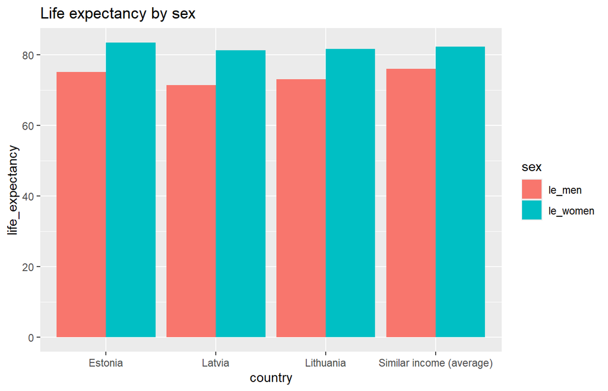

```r
# 6.1 Version 1: life expectancy of women and men, Baltic states and countries of similar income, 2024
baltic_and_similar <- gap_2024 |>
  filter(baltic) |>                                                   # the three Baltic states
  select(country, le_women, le_men) |>                                # their life expectancy, women and men
  bind_rows(tibble(country  = "Similar income (average)",            # add the comparison group as one more row
                   le_women = mean(similar_income$le_women),          # its average, women
                   le_men   = mean(similar_income$le_men))) |>        # its average, men
  pivot_longer(cols = c(le_women, le_men),                            # women and men into one column
               names_to = "sex", values_to = "life_expectancy")

baltic_and_similar |>
  ggplot(aes(x = country, y = life_expectancy, fill = sex)) +         # one bar per country, coloured by sex
  geom_col(position = "dodge") +                                      # women and men side by side
  labs(title = "Life expectancy by sex")                              # a title that names the topic, not the finding
```

```r
ggsave(here("figures", "graph_v1.png"), width = 8, height = 4.5, dpi = 300)   # save the version as an image
```

**The problem:** the bars run from 0 to about 83 years, as bars must, so a difference of 3 to 5 years between Baltic men and men in equally rich countries is a few millimetres and almost invisible. The reader cannot see the finding. On top of that, the title says only the topic, the legend shows the technical names `le_men` and `le_women`, the y axis has no unit, and the default colours carry no meaning.

## 6.2 Version 2: show the difference

Version 2 fixes the main problem of version 1 by changing the measure. Instead of total life expectancy, each bar shows how many years longer or shorter women and men in a Baltic state live than women and men in the ten countries of similar income. The difference starts at 0, so a shortfall of a few years becomes the length of the bar. Women and men get one panel each, and the axis says what is measured, in years.

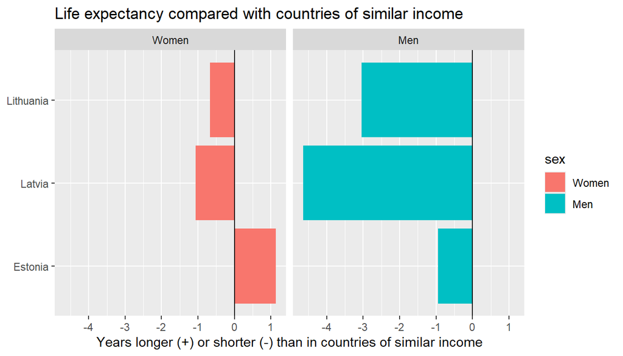

```r
# 6.2 Version 2: years longer or shorter than in countries of similar income, women and men, 2024
baltic_difference <- gap_2024 |>
  filter(baltic) |>                                                   # the three Baltic states
  mutate(Women = le_women - mean(similar_income$le_women),            # difference from the comparison group, women
         Men   = le_men   - mean(similar_income$le_men)) |>           # and men
  select(country, Women, Men) |>
  pivot_longer(cols = c(Women, Men),                                  # women and men into one column
               names_to = "sex", values_to = "difference") |>
  mutate(sex = factor(sex, levels = c("Women", "Men")))               # women in the left panel, men in the right

baltic_difference |>
  ggplot(aes(x = country, y = difference, fill = sex)) +              # one bar per country and sex
  geom_col() +                                                        # bar length = years longer (+) or shorter (-)
  geom_hline(yintercept = 0) +                                        # 0 = the same as in countries of similar income
  coord_flip() +                                                      # bars sideways, country names readable
  facet_wrap(~ sex) +                                                 # one panel for women, one for men
  labs(title = "Life expectancy compared with countries of similar income",   # still a topic, not a finding
       x = NULL,
       y = "Years longer (+) or shorter (-) than in countries of similar income")
```

```r
ggsave(here("figures", "graph_v2.png"), width = 8, height = 4.5, dpi = 300)   # save the version as an image
```

**What is better, and what is still missing:** the finding is now visible: the men’s bars point far to the left, the women’s stay close to 0. Still missing: the title names a topic instead of the finding, the legend repeats what the panel titles already say, the default colours have no meaning, the countries are in alphabetical order instead of by size, there are no numbers on the bars, no annotation and no source.

## 6.3 The final graph

The final graph keeps the measure and the panels of version 2 and refines them for the message, following the course principles:

- **Ask and Tell:** the title states the finding. One annotation points to the evidence: Latvian men’s life expectancy against that of men in equally rich countries.
- **Show:** the countries are ordered by the men’s shortfall, largest at the top, and every bar carries its number. The axis names the measure and the unit.
- **Cut:** no legend, because the panel titles already say women and men. No minor grid lines, no horizontal grid lines.
- **Focus:** gray plus one colour. The men’s bars are firebrick, the women’s gray, so the eye goes to the men. Firebrick is much darker than the gray, so the two can be told apart by lightness alone, also with colour blindness. The message does not depend on colour: the panel titles, the numbers and the annotation carry it too.
- **Readable:** `theme_minimal(base_size = 14)`, large enough for a slide.

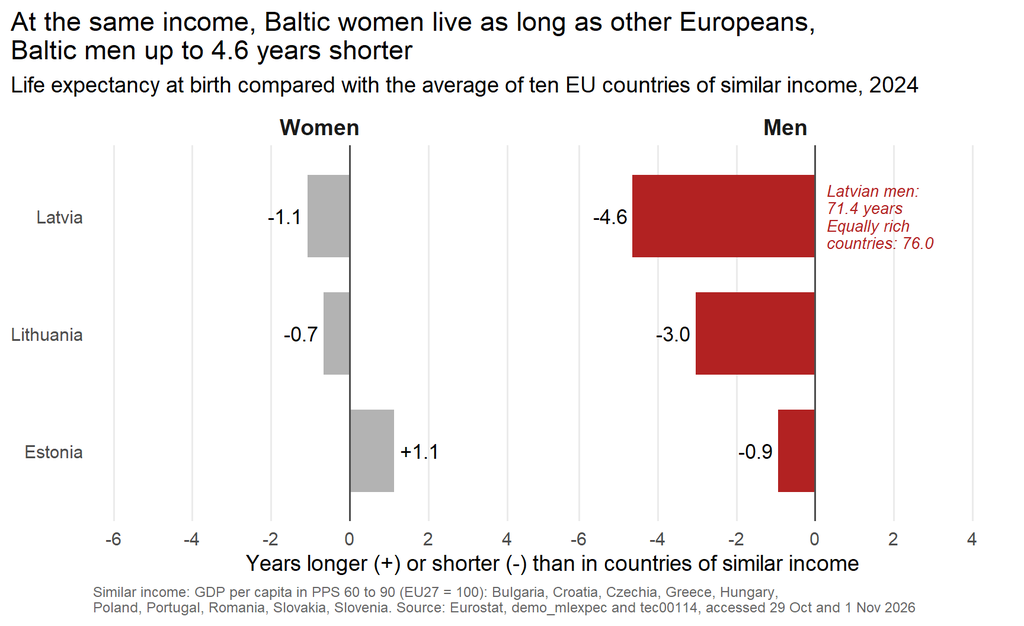

```r
# 6.3 The final graph: Baltic women and men against countries of similar income, 2024
latvia_men <- gap_2024 |> filter(country == "Latvia") |> pull(le_men)   # 71.4 years, for the annotation
similar_men <- mean(similar_income$le_men)                                # 76.0 years, for the annotation

final_graph <- baltic_difference |>
  mutate(country = fct_reorder(country, difference,
                               .fun = min, .desc = TRUE)) |>          # order by the men's shortfall, largest at the top
  ggplot(aes(x = country, y = difference, fill = sex)) +
  geom_col(width = 0.7) +                                             # bar length = years longer (+) or shorter (-)
  geom_hline(yintercept = 0, colour = "gray30") +                     # 0 = the same as in countries of similar income
  geom_text(aes(label = sprintf("%+.1f", difference),                 # the number with its sign, one decimal
                hjust = if_else(difference < 0, 1.15, -0.15)),        # just outside the end of the bar
            size = 4.5) +
  geom_text(data = tibble(sex = factor("Men", levels = c("Women", "Men")),   # the annotation, only in the men's panel
                          country = "Latvia", difference = 0.3,
                          label = sprintf("Latvian men:\n%.1f years\nEqually rich\ncountries: %.1f",
                                          latvia_men, similar_men)),
            aes(label = label), hjust = 0, size = 3.6, lineheight = 0.9,
            colour = "firebrick", fontface = "italic") +
  coord_flip(clip = "off") +                                          # bars sideways, labels may reach past the panel edge
  facet_wrap(~ sex) +                                                 # one panel for women, one for men
  scale_fill_manual(values = c("Women" = "gray70",                    # gray for the women
                               "Men"   = "firebrick")) +              # one colour for the men, the message
  scale_y_continuous(limits = c(-6, 4.5),                             # room for the numbers and the annotation
                     breaks = seq(-6, 4, by = 2)) +
  labs(title = "At the same income, Baltic women live as long as other Europeans,\nBaltic men up to 4.6 years shorter",   # the finding
       subtitle = "Life expectancy at birth compared with the average of ten EU countries of similar income, 2024",
       x = NULL,
       y = "Years longer (+) or shorter (-) than in countries of similar income",
       caption = paste0("Similar income: GDP per capita in PPS 60 to 90 (EU27 = 100): Bulgaria, Croatia, Czechia, Greece, Hungary,\n",
                        "Poland, Portugal, Romania, Slovakia, Slovenia. Source: Eurostat, demo_mlexpec and tec00114, accessed 29 Oct and 1 Nov 2026")) +
  theme_minimal(base_size = 14) +                                     # a clean theme, text large enough for a slide
  theme(legend.position = "none",                                     # the panel titles already name women and men
        plot.title.position = "plot",                                 # the title starts at the left edge of the image
        plot.caption = element_text(hjust = 0, size = 9, colour = "gray40"),
        strip.text = element_text(face = "bold", size = 14),          # panel titles easy to read
        panel.grid.minor = element_blank(),                           # fewer lines that carry no data
        panel.grid.major.y = element_blank())

final_graph
```

```r
ggsave(here("figures", "final_graph.png"), final_graph, width = 9, height = 5.5, dpi = 300)   # save the final graph
```

**What it shows:** at the same level of income, Baltic women live about as long as women in other EU countries, between 1.1 years shorter (Latvia) and 1.1 years longer (Estonia). Baltic men live shorter lives in all three countries: 4.6 years in Latvia, 3.0 in Lithuania and 0.9 in Estonia. The gap in the Baltic states is a gap of men.

## 6.4 Colour blind check

**Palette:** gray (`gray70`) for women and firebrick for men, the course’s “gray plus one colour”. The two colours differ strongly in lightness, so they stay apart even when the hue cannot be seen.

**Simulator:** Coblis, Color Blindness Simulator (https://www.color-blindness.com/coblis-color-blindness-simulator/), with the final graph uploaded and deuteranopia (red and green weakness, the most common type) selected.

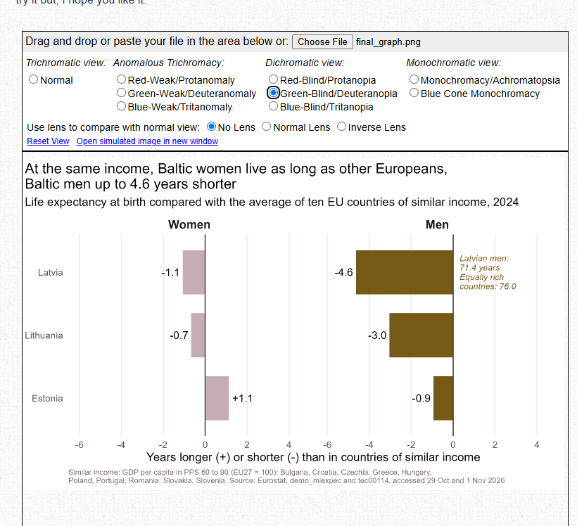

The final graph in a colour blindness simulator (Coblis, deuteranopia)

**Result:** the screenshot shows the simulator set to Green-Blind/Deuteranopia. Firebrick turns olive brown and the gray turns a light pinkish gray. The men’s bars are still much darker than the women’s, so the two groups remain easy to tell apart. The message does not rely on colour alone: the panel titles say “Women” and “Men”, every bar carries its number, and the annotation names Latvian men.

## 6.5 Log of the versions

| Version | File | What changed | Why |
| --- | --- | --- | --- |
| 1 | `figures/graph_v1.png` | First draft: total life expectancy of women and men as bars, default colours, a legend, a topic title | To see the raw numbers first. Problem: on bars from 0 to 83 years, a shortfall of 3 to 5 years is almost invisible |
| 2 | `figures/graph_v2.png` | The measure changed to the difference from countries of similar income, one panel for women and one for men, an axis label with the unit | A difference starts at 0, so the shortfall becomes the length of the bar and the finding is visible |
| Final | `figures/final_graph.png` | Finding as the title, gray plus firebrick, no legend, countries ordered by the men’s shortfall, numbers on the bars, one annotation, source line, larger text | So the eye goes to the men, the graph can be read without colour, and it works on a slide |

## 6.6 Answer to the question

**Answer:** at the same level of income, Baltic women live about as long as women in other EU countries, but Baltic men live shorter lives, in 2024 up to 4.6 years shorter in Latvia (71.4 years against 76.0 in ten EU countries of similar income), and the gap goes most closely with men’s extra deaths before 65 from heart disease and external causes. One limit: these are country averages, so they show which factors go together with the gap, not what causes it.

# 7. Limits

The data shows which deaths make up the gap and where the Baltic states stand, but it cannot say why. Six limits matter most when reading the results.

1. **Association, not cause.** With 27 countries, the analysis shows which factors go together with the gap, not what causes it. The three death factors also go together with each other (0.77 to 0.84, 5.9.2), so their effects cannot be separated.
2. **Country averages, not people.** Every number is a national figure. That countries with more alcohol-related deaths have larger gaps does not show that the men who drink are the ones who die earlier. Conclusions about individuals would need data on individuals.
3. **The death factors are part of the gap.** Life expectancy is calculated from death rates, so men’s extra deaths are, in part, the gap itself. Their close link with the gap describes what the gap is made of rather than explaining it from outside. Only deaths under 65 were analysed, and the deaths of older men add to the gap too.
4. **Life expectancy is a snapshot.** It assumes that the death rates of one year stay the same for a whole life. It describes the health of a country in that year, not how long a baby born today will actually live. Some values for 2024 are provisional.
5. **The final graph rests on one choice of comparison.** “Countries of similar income” means a GDP index between 60 and 90. A wider or narrower band changes the comparison countries and the exact numbers, but not the pattern. With bands of 50 to 100, 55 to 95 and 65 to 85, Latvian men live between 4.1 and 6.1 years shorter than men in the comparison group, and in every band and every Baltic state the men fall 1.9 to 4.0 years further behind than the women.
6. **Gaps in the data.** Deaths by cause end in 2023. Luxembourg has no healthy life years for 2023 and 2024. Education has a break in 2021, when the survey method changed. GDP overstates the income of residents in Luxembourg and Ireland. The alcohol figures end in 2020, are for women and men together, and measure how much is drunk, not how: heavy drinking concentrated among men cannot be seen in them.

# Appendix: dead ends

Relationships that were expected but turned out weak, and what was done about them. They are kept here, not deleted, because a weak result is also a result.

[output not shown]